# Linear Regression Workshop

Bill Kayser

2018-03-11 New Relic Slides available at http://bkayser.github.io/linear-regression-workshop

exclude: true

```r
library(knitr)
knitr::opts_chunk$set(echo = T,
                      messages=F,
                      warning=F,
                      error = F,
                      cache=T,
                      fig.width=11,
                      fig.asp=0.5,
                      fig.align = 'center',
                      out.width = '800px'
                      )
```

# Workshop Overview

- Linear Regression using `lm()`
- Polynomial Regression
- Feature Engineering
- Diagnostic Plots
- `ggplot` library
- Bonus?
  - GAMs
  - Performance Modeling

–

Follow along:

`tidyverse` loads in packages around Hadley Wickham’s principles of tidy data.

```r
library(tidyverse)
```

Some other libraries required for processing dates and doing Generalized Additive Models.

```r
library(lubridate)
library(gam)
```

layout: false

## Load Data

This is a sample set of transaction data in a 10 minute timeseries.

```r
data <- readRDS(gzcon(url("https://bit.ly/rpm-workshop-data")))
```

–

```r
data
```

```r
summary(data$throughput)
```

```
   Min. 1st Qu.  Median    Mean 3rd Qu.    Max.
 263900  358400  472600  484400  586400  716900
```

–

```r
summary(data$timestamp)
```

```
                 Min.               1st Qu.                Median
"2017-08-24 00:00:00" "2017-08-30 23:57:30" "2017-09-06 23:55:00"
                 Mean               3rd Qu.                  Max.
"2017-09-06 23:55:00" "2017-09-13 23:52:30" "2017-09-20 23:50:00"
```

–

```r
summary(data$start_time)
```

Throughput by Hour of Month

```r
ggplot(data) + aes(x=timestamp, y=throughput) +
    geom_point(size=0.2) +
    scale_x_datetime(date_labels='%F ')
```

Colored by Day of Week

```r
(g <- ggplot(data) + aes(x=start_time, y=throughput) +
    geom_point(aes(color=day), alpha=0.6, size=0.5) +
    scale_x_datetime(date_labels='%H:%m'))
```

layout: true

### Simple Linear Regression

Create a function to estimate the relationship between the time of day and the throughput using the form:

$$f(x) = \beta_0 +\beta_1x$$
where $f(x)$ is the function that predicts throughput given the minute of the day $x$.

–

```r
model.linear <- lm(throughput ~ minute_of_day, data=data)
model.linear
```

Predict the throughput at 3:00 pm.

```r
minute_of_day.3pm <- as.numeric(dhours(15), unit='minutes') # 900
beta <- coef(model.linear)
beta[1] + minute_of_day.3pm * beta[2]
```

What does $f(x)$ look like?

–

First create a dataset of synthetic x values, consisting of a time series of consecutive 10 minute periods over 24 hours. –

```r
minute_of_day <- seq(0, 24 * 60 - 1, 10)
predictions <- data.frame(minute_of_day,
                          start_time = min(data$start_time) + dminutes(minute_of_day))
head(predictions, 10)
```

Now use the model to augment our synthetic predictors with values predicted by the linear model:

```r
predictions$throughput <- predict(model.linear, newdata=predictions)
```

–

```r
select(predictions, minute_of_day, throughput) %>% head(10) %>% kable(format='html')
```

| minute_of_day | throughput |
| --- | --- |
| 0 | 547778.1 |
| 10 | 546891.6 |
| 20 | 546005.0 |
| 30 | 545118.5 |
| 40 | 544231.9 |
| 50 | 543345.4 |
| 60 | 542458.8 |
| 70 | 541572.3 |
| 80 | 540685.7 |
| 90 | 539799.2 |

## That’s our baseline!

Next, plot $f(x)$…

```r
g + geom_line(aes(x=start_time, y=throughput), color='red', size=1, data=predictions)
```

Show more detail on the model using the `summary(...)` function.

```r
summary(model.linear)
```

layout: true

### Polynomial Regression

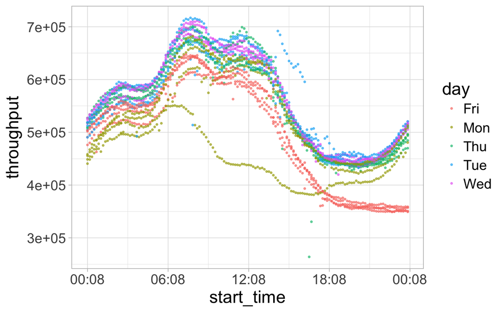

```r
(g.midweek <- ggplot(data.midweek) +
     geom_point(aes(x=start_time, y=throughput, color=day), alpha=0.6, size=0.5) +
     scale_x_datetime(date_labels='%H:%m'))
```

Now recalculate the linear model and predictions without the weekend data.

```r
model.midweek.linear   <- lm(throughput ~ minute_of_day, data=data.midweek)
predictions$throughput <- predict(model.midweek.linear, newdata=predictions)
```

–

```r
head(predictions, 10) %>% kable(format='html',)
```

```r
g.midweek + geom_line(aes(x=start_time, y=throughput), color='red', size=1,
                      data=predictions)
```

#### Using Quadratic Coefficents

Use quadratic terms for the minute of the day.
$$f(x) = \beta_0 + \beta_1x + \beta_2x^2$$
…where $x$ is the time of day.

–

In the R `lm()` function you represent a quadratic function as a formula that looks like this:

```r
throughput ~ I(minute_of_day**2) + minute_of_day
```

```r
model.midweek.quadratic <- lm(throughput ~ I(minute_of_day**2) + minute_of_day,
                              data=data.midweek)
summary(model.midweek.quadratic)
```

Regenerate throughput prediction using the quadratic model.

```r
predictions$throughput <- predict(model.midweek.quadratic, newdata=predictions)
```

–

```r
head(predictions, 10) %>% kable(format='html',)
```

### Throughput prediction using a quadratic function

```r
g.midweek + geom_line(data=predictions,
                      aes(x=start_time, y=throughput),
                      color='red', size=1)
```

### Using higher order polynomials

Use higher degree polynomial via `poly()` function in the formula.

```r
model.midweek.poly <- lm(throughput ~ poly(minute_of_day, 9), data=data.midweek)
```

–

This yields a model with 10 coefficents:

$$f(x) = \beta_0 + \beta_1x^1 + \beta_2x^2 + \beta_3x^3 ... \beta_9x^9$$
—

```r
summary(model.midweek.poly)
```

```
Call:
lm(formula = throughput ~ poly(minute_of_day, 9), data = data.midweek)

Residuals:
    Min      1Q  Median      3Q     Max
-204992  -18280   10930   25193  133084

Coefficients:
                          Estimate Std. Error t value Pr(>|t|)
(Intercept)               538695.5      779.2 691.353  < 2e-16 ***
poly(minute_of_day, 9)1 -2827726.6    41815.7 -67.624  < 2e-16 ***
poly(minute_of_day, 9)2 -2371285.7    41815.7 -56.708  < 2e-16 ***
poly(minute_of_day, 9)3  1843026.5    41815.7  44.075  < 2e-16 ***
poly(minute_of_day, 9)4  1279018.3    41815.7  30.587  < 2e-16 ***
poly(minute_of_day, 9)5  -376947.7    41815.7  -9.014  < 2e-16 ***
poly(minute_of_day, 9)6  -415504.0    41815.7  -9.937  < 2e-16 ***
poly(minute_of_day, 9)7   150773.7    41815.7   3.606 0.000317 ***
poly(minute_of_day, 9)8   -54954.7    41815.7  -1.314 0.188880
poly(minute_of_day, 9)9   311668.7    41815.7   7.453  1.2e-13 ***
---
Signif. codes:  0 ‘***’ 0.001 ‘**’ 0.01 ‘*’ 0.05 ‘.’ 0.1 ‘ ’ 1

Residual standard error: 41820 on 2870 degrees of freedom
Multiple R-squared:  0.7918,    Adjusted R-squared:  0.7912
F-statistic:  1213 on 9 and 2870 DF,  p-value: < 2.2e-16
```

### Plot the polynomial predictor

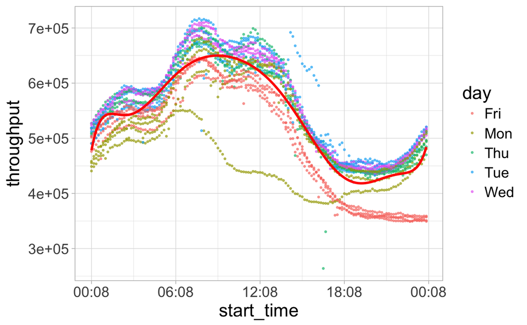

```r
predictions$throughput <- predict(model.midweek.poly, newdata=predictions)
g.midweek + geom_line(aes(x=start_time, y=throughput), data=predictions, color='red', size=1)
```

layout: true

### Multiple Regression

First, add two new variables to the data frame:

```r
data.midweek$minute_of_day.cos <- cos(data.midweek$minute_of_day*2*pi/1440)
data.midweek$minute_of_day.sin <- sin(data.midweek$minute_of_day*2*pi/1440)
```

–

Create the new model with the two derived variables.

```r
model.midweek.radial <- lm(throughput ~ minute_of_day.cos + minute_of_day.sin,
                           data=data.midweek)
```

–

```r
summary(model.midweek.radial)
```

To assess the model update our predictions with the new features, then recalculate the predicted throughput.

```r
predictions <- mutate(predictions,
                      minute_of_day.cos = cos(minute_of_day*2*pi/1400),
                      minute_of_day.sin = sin(minute_of_day*2*pi/1400))
predictions$throughput <- predict(model.midweek.radial, newdata=predictions)
```

–

```r
head(predictions)
```

```r
g.midweek + geom_line(aes(x=start_time, y=throughput),
                      data=predictions, color='red', size=1)
```

layout: true

### Combining Radial and Polynomial

Use a formula with the `poly()` function:

```r
throughput ~ poly(minute_of_day.cos, 3) + poly(minute_of_day.sin, 3)
```

–

```r
model.midweek.combined <-
    lm(throughput ~ poly(minute_of_day.cos, 3) + poly(minute_of_day.sin, 3),
       data=data.midweek)
```

```r
summary(model.midweek.combined)
```

### Bonus question

```r
coef(model.midweek.combined)
```

|  | x |
| --- | --- |
| (Intercept) | 538695.48 |
| poly(minute_of_day.cos, 3)1 | -2566700.61 |
| poly(minute_of_day.cos, 3)2 | 662604.33 |
| poly(minute_of_day.cos, 3)3 | 138557.76 |
| poly(minute_of_day.sin, 3)1 | 3438730.02 |
| poly(minute_of_day.sin, 3)2 | NA |
| poly(minute_of_day.sin, 3)3 | 25416.21 |

Update the predictions data with the combined model predictions.

```r
predictions$throughput <- predict(model.midweek.combined, newdata=predictions)
g.midweek + geom_line(aes(x=start_time, y=throughput),
                      data=predictions, color='red', size=1)
```